# homework from SA23204182

zhang Yan

2023-12-03

## 目录

您可以点击以下作业序号, 将自动跳转到相应位置

- hw0
- hw1
- hw2
- hw3
- hw4
- hw5
- hw6
- hw7
- hw8
- hw9

## hw0

### hw0_Example 1.

这是一个Metropolis-Hastings算法实例. 提议分布对称情况下，即g(X|Y)=g(Y|X)情况下，接受概率为：
$$\alpha(X_{t},Y)=min\left\{
1,\frac{f(Y)}{f(X_{t})} \right \} .$$

代码如下：过程中生成了四个马氏链，分别对应不同收敛速度。计算拒绝率并绘制链图。

```r
set.seed(111)
indept.Metropolis <- function(sigma_g, x0, N){#链生成
  #sigma_g为提议方差 x0为初始值 N链长
    x = numeric(N)
    x[1] = x0
    u = runif(N)
    k = 0
    for(i in 2:N){
      y = rnorm(1, x[i-1], sigma_g)
      porb = (1+x[i-1]^2) / (1+y^2)
      if(u[i] <= porb)
        x[i] = y
      else{
        x[i] = x[i-1]
        k = k + 1
      }
    }
    return(list(x=x, k=k))
  }
chain_len = 5000
xt = numeric(chain_len)
sigma_g = c(0.05, 0.5, 2.5, 16)
x0 <- 3   # initial point
  indept1 <- indept.Metropolis(sigma_g[1], x0, chain_len)
  indept2 <- indept.Metropolis(sigma_g[2], x0, chain_len)
  indept3 <- indept.Metropolis(sigma_g[3], x0, chain_len)
  indept4 <- indept.Metropolis(sigma_g[4], x0, chain_len)
print(c(indept1$k, indept2$k, indept3$k, indept4$k)/chain_len)#四个链的拒绝率
```

```
## [1] 0.0076 0.1014 0.4094 0.8122
```

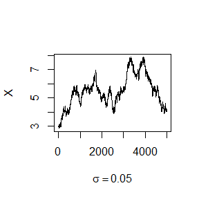

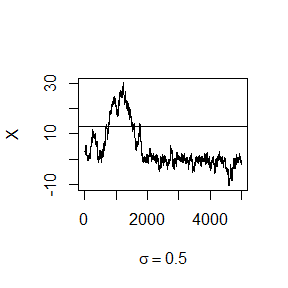

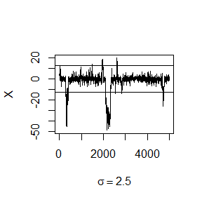

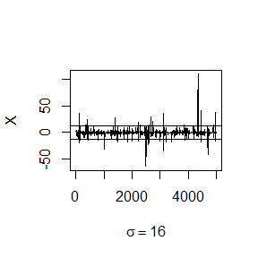

```r
  refline <- qcauchy(c(.025, .975))
  indept <- cbind(indept1$x, indept2$x, indept3$x, indept4$x)
  for (j in 1:4) {
      plot(indept[,j], type="l",
           xlab=bquote(sigma == .(round(sigma_g[j],3))),
           ylab="X", ylim=range(indept[,j]))
      abline(h=refline)
  }
```

只有第三个链的拒绝率在[0.15，0.5]范围内，但第四个链收敛性最好。

### hw0_Example 2.

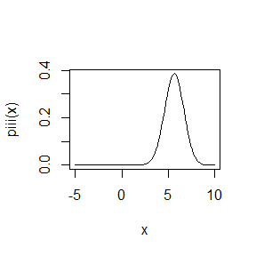

```r
ffpi<-function(theta){
  1/(1+theta^2)*exp(-(theta-6)^2/2)
}
piii<-function(theta){
  z <- integrate(ffpi,-Inf,Inf)$value
  y <- ffpi(theta)/z
  y
}#后验分布
curve(piii,-5,10)
```

```r
#单峰
```

```r
quantt1 <- function(x){
   integrate(piii,-Inf,x)$value-0.025
}
quantt2 <- function(x){
   integrate(piii,-Inf,x)$value-0.975
}
x025<-uniroot(quantt1,c(-5,10))$root
x975<-uniroot(quantt2,c(-5,10))$root
qq1<-piii(x025)
qq2<-piii(x975)
x025;x975
```

```
## [1] 3.609745
```

```
## [1] 7.659627
```

```r
repeat{
kk<-(qq1+qq2)/2
ppkk <- function(theta,kk){
  y <- piii(theta)-kk
  y
}
cc1<- uniroot(ppkk,c(0,6),kk=kk)$root
cc2<- uniroot(ppkk,c(6,10),kk=kk)$root
ppp<- integrate(piii,cc1,cc2)$value
   if (abs(ppp-0.95)<=0.0001) break
   if (p-0.95>0)  qq2<-kk
   else  qq1<-kk
   }
ppp  #HPD可信区间的可信度
```

```
## [1] 0.9499881
```

```r
cc1;cc2
```

```
## [1] 3.618324
```

```
## [1] 7.667858
```

## hw1

### hw1_1.利用逆变换方法实现sample部分功能

```r
my.sample1 =function(x,pro,size){#总体 概率 样本容量
  cdfpro<- cumsum(pro); m <- size; U = runif(m)#根据pro求分布函数Fx,并生成U
  r <- x[findInterval(U,cdfpro)+1]#逆变换
  ct <- as.vector(table(r))
  print(c("各元素被抽中频率：",ct/m))
  return(r)
}

x <- c("a","b","c","d"); pro <- c(.1,.1,.3,.5)#抽样总体与概率
my.sample1(x,pro,100)
```

```
## [1] "各元素被抽中频率：" "0.09"               "0.08"
## [4] "0.27"               "0.56"
```

```
##   [1] "c" "d" "c" "d" "c" "c" "d" "d" "d" "d" "d" "d" "d" "d" "b" "c" "c" "d"
##  [19] "c" "d" "b" "d" "d" "d" "d" "d" "c" "d" "c" "a" "d" "d" "d" "d" "d" "a"
##  [37] "d" "d" "c" "b" "c" "b" "c" "d" "d" "d" "c" "d" "d" "d" "d" "a" "b" "d"
##  [55] "d" "d" "d" "b" "c" "a" "c" "c" "d" "b" "a" "c" "c" "d" "a" "d" "a" "d"
##  [73] "d" "d" "d" "d" "d" "d" "c" "b" "c" "c" "d" "a" "c" "c" "c" "c" "c" "d"
##  [91] "d" "c" "d" "d" "d" "d" "d" "a" "d" "d"
```

复现功能sample(x[x>5], 100, replace = TRUE),其中x<-c(1,3,5,7,9,8)。即从(1,3,5,7,9,8)中进行 放回 等概率 条件（>5）抽样。

```r
my.sample2 = function(x,size,Lower_bound){#条件抽样 抽高于Lower_bound的元素
  xr<-0
  xx<-c()#x中符合条件的角标
  for (i in 1:length(x)){
    if (x[i]>Lower_bound){
      xr=xr+1
      xx<-c(xx,i)
    }
  }
  if (length(xx)==0)
    stop("没有符合条件的元素！")
  U = runif(size)#抽样数目
  cdfp=1:length(xx)/length(xx)
  return(x[xx[findInterval(U,cdfp)+1]])
}

x <- c(1,3,5,7,9,8)#抽样总体
my.sample2(x,100,5)
```

```
##   [1] 8 9 8 7 7 8 7 8 7 7 7 8 8 9 7 7 7 9 7 7 9 7 9 8 9 8 9 7 7 8 8 9 8 8 7 8 7
##  [38] 8 9 9 7 9 7 9 9 8 7 8 7 7 8 8 9 8 9 7 9 7 9 7 7 9 8 9 9 8 8 8 7 9 8 9 9 7
##  [75] 9 9 7 7 8 7 9 9 8 7 8 8 9 7 9 7 8 8 9 9 7 7 9 7 9 7
```

### hw1_2.Exercise 3.2

Q：The standard Laplace distribution has density $f(x)=\frac{1}{2}e^{-|x|},x\in \mathbb{R}$. Use the inverse transform method to generate a random sample of size 1000 from this distribution. Use one of the methods shown in this chapter to compare the generated sample to the target distribution.

A： Laplace的分布函数为
$$F_{X}(x)=\int_{-\infty }^{x}f(t)dt=\begin{cases}
& \frac{1}{2}e^{x} \quad \qquad \ \text{ if } x\leq 0 \\
& 1-\frac{1}{2}e^{-x} \quad \text{ if } x > 0
\end{cases},$$
则逆函数
$$F_{X}^{-1}(x)=\begin{cases}
& \ln (2x) \qquad \qquad \text{ if } x\leq \frac{1}{2} \\
& -\ln 2(1-x)\ \quad \text{ if }x > \frac{1}{2}
\end{cases},$$
若$U \sim Uniform(0,1)$，那么$F_{X}^{-1}(U)$has the same distribution as X.

算法如下：

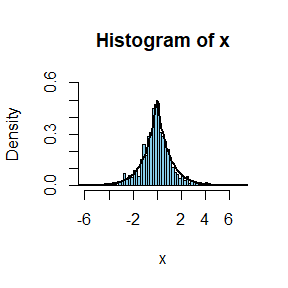

```r
fni=function(x){
  if (x<=0.5)
    return(log(2*x))
  if (x>0.5)
    return(-log(2*(1-x)))
}#逆函数
x<-c()
U = runif(1000)
for (i in U) {
  x<-c(x,fni(i))
}#代入逆函数
minx =floor(min(x))
maxx = floor(max(x))+1
hist(x,probability = TRUE,ylim = c(0,0.6),xlim = c(minx,maxx),
     breaks = seq(minx,maxx,by = 0.2),col = "skyblue")
y <- seq(-10,10,0.1)
lines(y,0.5*exp(-abs(y)),lwd = 2) #绘制直方图与密度函数图像进行对比
```

### hw1_3.Exercise 3.7

Q：Write a function to generate a random sample of size n from the Beta(a, b) distribution by the acceptance-rejection method. Generate a random sample of size 1000 from the Beta(3,2) distribution. Graph the histogram of the sample with the theoretical Beta(3,2) density superimposed.

A：Beta(3,2)的概率密度函数为：$f(x)=12x^{2}(1-x)$,(0<x<1). $\max_{x \in (0,1)} f(x)=\frac{16}{9}$，故取$g(x)=1,(x\in(0,1)),c=2$. 使用acceptance-rejection 方法进行取样并画图，代码如下。

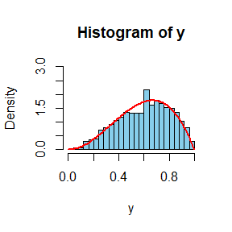

```r
n <- 1e3;j<-k<-0;y <- numeric(n)#k样本数，y样本
while (k < n) {
  u <- runif(1)
  j <- j + 1#试验次数
  x <- runif(1) #产生新候选样本x
  if (12*x*x*(1-x)>2*u) {
    #接受x
    k <- k + 1
    y[k] <- x
  }
}
hist(y,probability = TRUE,ylim = c(0,3),xlim = c(0,1),breaks = seq(0,1,by = 0.04),col = "skyblue")
z <- seq(0,1,0.01)
lines(z,12*z*z*(1-z),lwd = 2,col="red") #绘制直方图与pdf曲线
```

```r
print(c("接受率为：",k/j))
```

```
## [1] "接受率为："        "0.516262261228704"
```

### hw1_4.Exercise 3.9

Q: The rescaled Epanechnikov kernel is a symmetric density function
$$f_{e}(x)=\frac{3}{4}(1-x^{2}),|x|\le 1.$$
. Devroye and Gyorfi give the following algorithm for simulation from this distribution. Generate iid $U_{1},U_{2},U_{3}\sim Uniform(−1, 1)$. If $|U_{3}|\ge|U_{2}|\ and\ |U_{3}\ge |U_{1}|$, deliver $U_{2}$; otherwise deliver $U_{3}$. Write a function to generate random variates from $f_{e}$, and construct the histogram density estimate of a large simulated random sample.

A: 代码如下，按照题干中的接受样本方式生成了10000个样本，并绘制了直方图、pdf（黑）与密度估计曲线（红）。

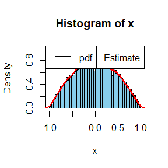

```r
n <- 1e4;j<-k<-0;x <- numeric(n)#k样本数，x样本
while (k < n) {
  u<- runif(3,min=-1,max=1)
  j <- j + 1#试验次数
  if (abs(u[3])>abs(u[2]) & abs(u[3])>abs(u[1])) {
    #接受u2
    k <- k + 1
    x[k] <- u[2]
  }
  else {
    k <- k + 1
    x[k] <- u[3]
  }
}
density_e <- density(x)
hist(x,probability = TRUE,ylim = c(0,1),xlim = c(-1,1),breaks = seq(-1,1,by = 0.04),col = "skyblue")
y <- seq(-1,1,0.01)
lines(y,0.75*(1-y*y),lwd = 2) #绘制直方图与pdf曲线
lines(density_e, col = "red", lwd = 2)
legend("topright", legend = "Estimate", col = "red", lwd = 2)
legend("topleft", legend = "pdf", col = "black", lwd = 2)
```

### hw1_5.Exercise 3.10

Q：Prove that the algorithm given in Exercise 3.9 generates variates from the density $f_{e}$.

A：记3.9中方法生成的随机变量为X。并同时按照以下方法生成Y。

> If $|U_{3}|\ge|U_{2}|\ and\ |U_{3}\ge |U_{1}|$, deliver $U_{1}$; if $|U_{2}|\ge|U_{1}|\ and\ |U_{2}\ge |U_{3}|$, deliver $U_{1}$; otherwise deliver $U_{3}$.

另记$M=max\{|U_{1}|,|U_{2}|,|U_{3}|\}$, 则$p(M<m)=p(|U_{1}|<m,|U_{2}|<m,|U_{3}|<m)=m^{3}$, 则M的pdf为$f_{M}(m)=3m^{2}$.

则$\{|X|,|Y|,M\}=\{|U_{1}|,|U_{2}|,|U_{3}|\}$，故$f_{|X|}(x)+f_{|Y|}(x)+f_{M}(x)=f_{|U_{1}|}(x)+f_{|U_{2}|}(x)+f_{|U_{3}|}(x)=3$. 其中由于|X|与|Y|的生成方式一致（每次都是选择非最大量的其中一个），故$f_{|X|}(x)=f_{|Y|}(x)$.

故
$$f_{|X|}(x)=\frac{1}{2}(3-f_{M}(x))=\frac{3}{2}(1-x^{2}).$$

由于$X$为对称分布，故
$$f_{X}(x)=\frac{1}{2} \cdot
f_{|X|}(x)=\frac{3}{4}(1-x^{2}).$$

## hw2

### hw2_1. Buffon’s niddle experiment

#### hw2_1.1 $\rho^{*}=argmin_{\rho}\{Var(\hat{\pi})\}$

Q: Proof that what value $\rho=l/d$ should take to minimize the asymptotic variance of $\hat{\pi}$? $m \sim B(n,p), use\ \delta$ method. Note the best as $\rho^{*}$.

A: 根据$\frac{m}{n}=\frac{2l}{d\pi}$, 我们对$\pi$的估计为
$$\hat{\pi}=2\rho\frac{n}{m},$$
其中$m \sim B(n,p)$, $p=2\rho/\pi$. 由于m可以看作n次独立B(1,p)实验结果的和，所以根据中心极限定理$\frac{m}{n}$的渐近方差
$$Var^{*}(\frac{m}{n})=\frac{1}{n}Var(B(1,p))=\frac{p(1-p)}{n}.$$
根据$\delta$方法，$\hat{\pi}$的渐近方差
$$Var^{*}(\hat{\pi})=(2\rho)^{2}\cdot\frac{Var^{*}(\frac{m}{n})}{(\mathbb{E}[m/n])^{4}}=(2\rho)^{2}\cdot\frac{p(1-p)}{np^{4}}=\frac{\pi^2(\pi-2\rho)}{2n\rho}.$$
显然，在[0,1]上，$Var^{*}(\hat{\pi})$随$\rho$单调递减，进而在$\rho^{*}=1$处取得最小值。 #有一种$\rho$越大，样本中有效信息越多的感觉。

#注意：这里n为实验次数，m为成功次数。和ppt相反

#### hw2_1.2 MC

Q: Take three different values of $\rho$ $(0\leq \rho \leq1$, including $\rho_{min}$) and use Monte Carlo simulation to verify your answer. (n = $10^{6}$, Number of repeated simulations K = 100)

A: 取$(\rho_{1},\rho_{2},\rho_{3})=(0.5,0.8,1).$用MC方法进行模拟如下：

```r
set.seed(1234)
l <- c(0.5,0.8,1)
d <- 1
m <- 1e6
k<-100
X <- array(runif(m*k,0,d/2),dim=c(m,k))#随机数序号对应行、实验序号对应不同列
Y <- array(runif(m*k,0,pi/2),dim=c(m,k))
some<-outer(l/2,sin(Y))>outer(c(1,1,1),X)#张量积，在前面补充参数维数
#apply(some,c(1,3),mean)#1不同参数.2单次实验随机数。3.重复实验次数
pihat<-2*outer(l,array(1,dim = k))/apply(some,c(1,3),mean)#求估计
varpi<-apply(pihat,1,var)
varpi
```

```
## [1] 1.832521e-05 9.966356e-06 4.585881e-06
```

方差呈现降低趋势，符合前面的分析。

理论渐进方差为：

```r
varth<-(-1)*(pi)^2*(2*l-pi)/2/m/l
varth
```

```
## [1] 2.113667e-05 9.509319e-06 5.633534e-06
```

计算方差与理论的百分比差异:

```r
abs(varth-varpi)/varth
```

```
## [1] 0.13301370 0.04806202 0.18596723
```

### hw2_Exercises 5.6

Q: In Example 5.7 the control variate approach was illustrated for Monte Carlo integration of
$$\theta=\int_{0}^{1}e^xdx.$$
Now consider the antithetic variate approach. Compute $Cov(e^U,e^{1-U})$ and $Var(e^U+e^{1-U})$, where $U\sim$ Uniform(0,1). What is the percent reduction in variance of $\hat{\theta}$ that can be achieved using antithetic variates (compared with simple MC)?

A: 取 $h(U)=(e^U+e^{1-U})/2$ 为 $\theta$ 的无偏估计（$U\sim Uniform (0,1)$）。

$$Cov(e^U,e^{1-U})=\mathbb{E}[e]-\mathbb{E}^2[e^U]=e-(e-1)^{2}\doteq
-0.2342106,$$

$$Var(e^U+e^{1-U})=2Var(e^U)+2Cov(e^U,e^{1-U})=e^2-1+2e-4(e-1)^2\doteq0.0156500.$$
故而 $Var(h(U))=Var(e^U+e^{1-U})/4\doteq0.00391$.

只使用 $e^{U}$ 作为 $\theta$ 的估计(the simple Monte Carlo method)时，方差

$$Var(e^U)=\frac{e^2-1}{2}-(e-1)^2\doteq0.2420351$$

方差减小：
$$\frac{Var(e^U)-Var(h(U))}{Var(e^U)}\times
100\%=98.384\%$$
（注意这里数据对应两种方法采用了同样的样本U的数量。如果要求对偶方法只取一半，相应Var(h)为原来2倍。）

### hw2_Exercises 5.7

Q: Refer to Exercise 5.6. Use a Monte Carlo simulation to estimate $\theta$ by the antithetic variate approach and by the simple Monte Carlo method. Compute an empirical estimate of the percent reduction in variance using the antithetic variate. Compare the result with the theoretical value from Exercise 5.6.

A: 两种方法都重复100次实验，单次实验生成$10^3$个样本。Code:

```r
set.seed(1234)
m <- 1000
k=100
x <- array(runif(m*k),dim=c(m,k))
theta_anti <- apply((exp(x)+exp(1-x)) / 2,2,mean)#theta_anti <- apply((exp(x)+exp(1-x))[1:m/2,1:k]/ 2,2,mean)
theta_sim <- apply(exp(x),2,mean)
(var(theta_sim)-var(theta_anti))/var(theta_sim)
```

```
## [1] 0.9840003
```

基本符合理论计算结果。（注意这里两种方法采用了同样的样本U的数量，如果要求对偶方法只取一半，只需要相应替换为注释内的代码,相应百分比会降低）。

## hw3

### hw3_1.

A：(默认区间等长，g在(a,b)上平方可积,区间数k to 无穷)

只需证明：$Var(\theta_{I})/Var(\hat{\theta}^{M}) \to 1\ as\ b_{i}-a_{i}\to0\ for\ all\ i.$

由于$Var(\hat{\theta}^{M})$不随区间划分变化，所以只需证：
$$Var(\theta_{I})-Var(\hat{\theta}^{M}) \to 0\ as\
b_{i}-a_{i}\to0\ for\ all\ i.$$

而
$$Var(\theta_{I})-Var(\hat{\theta}^{M})=\int^{b}_{a}g^{2}(t)dt-\sum_i\left(
\int^{b_{i}}_{a_{i}}g(t)dt \right)^2\to 0\ as\ b_{i}-a_{i}\to0\ for\
all\ i.$$

### hw3_Exercises 5.13

Q： Find two importance functions $f_{1}$ and $f_{2}$ that are supported on $(1,\infty)$ and are ‘close’ to
$$g(x) =
\frac{x^2}{\sqrt{2\pi}}e^{-x^2/2},x>1.$$
Which of your two importance functions should produce the smaller variance in estimating
$$\int^\infty_1\frac{x^2}{\sqrt{2\pi}}e^{-x^2/2}dx$$
by importance sampling? Explain.

A: 选取$f_{1}$(对应正太分布N(1,1)),$f_{2}$(对应倒数为U(0,1)分布的随机变量):
$$f_{1}(x)=\frac{2}{\sqrt{2\pi}}e^{-(x-1)^2/2},f_{2}(x)=\frac{1}{x^2},x>1.$$
其与g(x)的图像如下

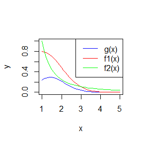

```r
#图像比对
x <- seq(1, 5, by = 0.1)
y1 <- x^2/sqrt(2*pi)*exp(-x^2/2)
y2 <- 2*exp(-(x-1)^2/2)/sqrt(2*pi)
y3 <- 1/x^2

plot(x, y1, type = "l", col = "blue", xlab = "x", ylab = "y",ylim=c(0,1))
lines(x, y2, col = "red")
lines(x, y3, col = "green")
legend("topright", legend = c("g(x)", "f1(x)","f2(x)"), col = c("blue", "red","green"), lty = 1)
```

记$X\sim N(1,1),1/Y\sim U(0,1)$

则
$$Var(g(|X|)/f_{1}(|X|))-Var(g(Y)/f_{2}(Y))
=E(g(|X|)/f_{1}(|X|))^2-E(g(Y)/f_{2}(Y))^2\\
=\int_1^\infty (\frac{g(x)}{f_{1}(x)})^2\cdot f_{1}(x)dx-\int_1^\infty
(\frac{g(x)}{f_{2}(x)})^2\cdot f_{2}(x)dx\\
=\int^\infty_{1}\frac{g^2(x)}{f_{1}(x)}-\frac{g^2(x)}{f_{2}(x)}dx$$
其中
$$\int^\infty_{1}\frac{g^2(x)}{f_{1}(x)}=\int^\infty_{1}\frac{x^4}{\sqrt{2\pi}}e^{-x^2/2-x+0.5}dx\doteq0.1624437,$$
$$\int^\infty_{1}\frac{g^2(x)}{f_{2}(x)}=\int^\infty_{1}\frac{x^6}{2\pi}e^{-x^2}\doteq
0.2538431.$$

所以第一种函数对应方差更小.

```r
f1<-function(x){
  return(x^4/2/sqrt(2*pi)*exp(-x^2/2-x+0.5))}
result1 <- integrate(f1, lower = 1, upper = Inf)
result1#f1对应的积分
```

```
## 0.1624437 with absolute error < 3.7e-06
```

```r
f2<-function(x){
  return(x^6/(2*pi)*exp(-x^2))}
result2 <- integrate(f2, lower = 1, upper = Inf)
result2#f2对应的积分
```

```
## 0.2538431 with absolute error < 3.4e-06
```

### hw3_Exercises 5.14

Q: Obtain a Monte Carlo estimate of
$$\int^\infty_1\frac{x^2}{\sqrt{2\pi}}e^{-x^2/2}dx$$
by importance sampling.

A: 选择$f_{1}$, R代码如下:

```r
set.seed(123)
x<-rnorm(100)
y<-abs(x-1)+1
gf<-function(x){#函数g/f
  return(x^2/sqrt(2*pi)*exp(-x^2/2)/(2*exp(-(x-1)^2/2)/sqrt(2*pi)))}
theta.hat<-mean(gf(y))

g<-function(x){#函数g(x)
  return( x^2/sqrt(2*pi)*exp(-x^2/2))
}
theta.real<-integrate(g, lower = 1, upper = Inf)
theta.hat;theta.real
```

```
## [1] 0.4005783
```

```
## 0.400626 with absolute error < 5.7e-07
```

估计值与积分值很接近.

### hw3_Exercises 5.15

Q： Obtain the stratified importance sampling estimate in Example 5.13 and compare it with the result of Example 5.10.

A:

```r
set.seed(1)
M <- 10000
g <- function(x) {#函数g(x)
exp(-x - log(1+x^2)) * (x > 0) * (x < 1)
}
u <- c(runif(M/5,0,0.2),runif(M/5,0.2,0.4),runif(M/5,0.4,0.6),runif(M/5,0.6,0.8),runif(M/5,0.8,1.0))#分层抽样

x<--log(1-u*(1-exp(-1)))
fg <- g(x)/exp(-x)*(1-exp(-1))

theta.hat <- mean(fg)#重要函数估计
fgr<-apply(array(fg,dim=c(M/5,5)),1,sum)/5#分层组合
se <- sd(fgr)
theta.hat;se
```

```
## [1] 0.5246884
```

```
## [1] 0.00944721
```

和Example 5.10相比，估值相近，标准差缩小为原来的十分之一左右。

### hw3_Exercises 6.5

Q： Suppose a 95% symmetric t-interval is applied to estimate a mean, but the sample data are non-normal. Then the probability that the confidence interval covers the mean is not necessarily equal to 0.95. Use a Monte Carlo experiment to estimate the coverage probability of the t-interval for random samples of χ2(2) data with sample size n = 20. Compare your t-interval results with the simulation results in Example 6.4. (The t-interval should be more robust to departures from normality than the interval for variance.)

A: $\chi^2(2)$的均值$\mu=2.$

```r
set.seed(123)
m=10000
n <- 20
alpha <- .05
torf<-numeric(m)
for (i in 1:m) {
  x <-rchisq(n, df=2)#rnorm(n)+2#
  torf[i] <-abs(2-mean(x)) <qt(1-alpha/2,df=n-1)*sqrt(var(x))/sqrt(n)#是否落入置信区间
}
sum(torf)/m
```

```
## [1] 0.9218
```

均值2落入t-区间的概率为0.9218,小于0.95.但与方差的置信区间相比,波动相对很小. 可以预见,当样本量增加时,均值落入t-区间的概率将更逼近0.95.

### hw3_Exercises 6.A

Q：Use Monte Carlo simulation to investigate whether the empirical Type I error rate of the t-test is approximately equal to the nominal significance level $\alpha$, when the sampled population is non-normal. The t-test is robust to mild departures from normality. Discuss the simulation results for the cases where the sampled population is (i) $\chi^2(1)$, (ii) Uniform(0,2), and (iii) Exponential(rate=1). In each case, test $H_{0} : \mu =\mu_{0}\ vs\ H_{1} : \mu \ne \mu_{0}$, where $\mu_{0}$ is the mean of $\chi^2(1)$, Uniform(0,2), and Exponential(1),respectively.

A: 先选择样本量n=20.

```r
n<-20;m<-10000;p1<-p2<-p3<-numeric(m)
for (i in 1:m) {#第一种卡方分布
  x<-rchisq(n,df=1)
  pz<-t.test(x,mu=1)
  p1[i]<-pz$p.value
}
mean(p1<0.05)#第一类错误率
```

```
## [1] 0.1073
```

```r
for (i in 1:m) {#第二种均匀分布
  x<-2*runif(n)
  pz<-t.test(x,mu=1)
  p2[i]<-pz$p.value
}
mean(p2<0.05)#第一类错误率
```

```
## [1] 0.0541
```

```r
for (i in 1:m) {#第三种指数分布
  x<-rexp(n)
  pz<-t.test(x,mu=1)
  p3[i]<-pz$p.value
}
mean(p3<0.05)#第一类错误率
```

```
## [1] 0.0838
```

可以看出, 均匀分布的t检验的第一类错误率最接近于$\alpha=0.05$, 其余两种实验的一类错误率都偏大. 但随着样本量增加(如n=100), 一类错误率都将更接近0.05.

```r
n<-100;m<-10000;p1<-p2<-p3<-numeric(m)
for (i in 1:m) {#第一种卡方分布
  x<-rchisq(n,df=1)
  pz<-t.test(x,mu=1)
  p1[i]<-pz$p.value
}
mean(p1<0.05)#第一类错误率
```

```
## [1] 0.0646
```

```r
for (i in 1:m) {#第二种均匀分布
  x<-2*runif(n)
  pz<-t.test(x,mu=1)
  p2[i]<-pz$p.value
}
mean(p2<0.05)#第一类错误率
```

```
## [1] 0.0469
```

```r
for (i in 1:m) {#第三种指数分布
  x<-rexp(n)
  pz<-t.test(x,mu=1)
  p3[i]<-pz$p.value
}
mean(p3<0.05)#第一类错误率
```

```
## [1] 0.0573
```

## hw4

### hw4_一:p-值矫正

Q：考虑m=1000个假设,其中前95%个原假设成立,后5%个对立假设成立.在原假设下,p-值服从U(0,1)分布,在对立假设下,p-值服从Beta(0.1,1)分布.应用Bonferroni矫正与B-H矫正应用于生成的m个p-值(独立)(应用p.adjust),得到矫正后的p-值,与$\alpha=0.1$比较是否拒绝原假设.基于M=1000次模拟，估计FWER,FDR,TPR并输出到表格中。

A：

```r
#setting
set.seed(1)
m<-1000;M<-1000
FWER1<-numeric(M);FDR1<-numeric(M);TPR1<-numeric(M)
FWER2<-numeric(M);FDR2<-numeric(M);TPR2<-numeric(M)
#compute
p<-numeric(m)#记录p值
for (i in 1:M) {
  p[1:950]<-runif(m*.95);p[951:m]<-rbeta(m*.05,0.1,1)
  p.adj1 = p.adjust(p,method='bonferroni')#p*N
  p.adj2 = p.adjust(p,method='fdr')#p*N/max(k)(就是有相同值时取大秩)
  #计算各值
  FWER1[i]<-sum(p.adj1[1:m*.95]<0.1)>0
  FWER2[i]<-sum(p.adj2[1:m*.95]<0.1)>0
  FDR1[i]<-sum(p.adj1[1:m*.95]<0.1)/sum(p.adj1<0.1)
  FDR2[i]<-sum(p.adj2[1:m*.95]<0.1)/sum(p.adj2<0.1)
  TPR1[i]<-sum(p.adj1[951:m]<0.1)/50
  TPR2[i]<-sum(p.adj2[951:m]<0.1)/50
}
```

进而最终的FWER,FDR,TPR如下。

|  | FWER | FDR | TPR |
| --- | --- | --- | --- |
| Bonferroni矫正 | 0.094 | 0.005 | 0.398 |
| B-H矫正 | 0.933 | 0.100 | 0.565 |

其中B-H矫正的FDR与Bonfferroni矫正的FWER接近0.1，但是Bonfferroni矫正的FDR为0.005，远小于0.1；B-H矫正的FWER为0.933，远大于0.1。比较二者的TPR，容易发现Bonfferroni矫正方法的TPR比B-H方法小。

### hw4_二:ppt_homework

- Homework
  - Suppose the population has the exponential distribution with rate $\lambda$, then the MLE of $\lambda$ is $\hat\lambda=1/\bar X$, where $\bar X$ is the sample mean. It can be derived that the expectation of $\hat\lambda$ is $\lambda n/(n-1)$, so that the estimation bias is $\lambda/(n-1)$. The standard error $\hat\lambda$ is $\lambda n/[(n-1)\sqrt{n-2}]$. Conduct a simulation study to verify the performance of the bootstrap method.
  - The true value of $\lambda=2$.
  - The sample size $n=5,10,20$.
  - The number of bootstrap replicates $B = 1000$.
  - The simulations are repeated for $m=1000$ times.
  - Compare the mean bootstrap bias and bootstrap standard error with the theoretical ones. Comment on the results.

Answer：代码如下:

```r
#setting
set.seed(1)
lammda<-2
n<-c(5,10,20);B<-1e3;m<-1e3
bias<-matrix(0, nrow =m, ncol = 3)
se<-matrix(0, nrow =m, ncol = 3)

#n=5时
for (k in 1:m) {
  x <- rexp(n[1],lammda)
  lamstar<-numeric(B)
  for(b in 1:B){
    xstar <- sample(x,replace=TRUE)
    lamstar[b]<-1/mean(xstar)
  }
  bias[k,1]<-mean(lamstar)-1/mean(x)
  se[k,1]<-sd(lamstar)
}
round(c(bias1=mean(bias[,1]),se1=mean(se[,1]),bias1.theo=lammda/(n[1]-1),se1.theo=lammda*n[1]/(n[1]-1)/sqrt(n[1]-2)),3)

#n=10时
for (k in 1:m) {
  x <- rexp(n[2],lammda)
  lamstar<-numeric(B)
  for(b in 1:B){
    xstar <- sample(x,replace=TRUE)
    lamstar[b]<-1/mean(xstar)
  }
  bias[k,2]<-mean(lamstar)-1/mean(x)
  se[k,2]<-sd(lamstar)
}
round(c(bias2=mean(bias[,2]),se2=mean(se[,2]),bias2.theo=lammda/(n[2]-1),se2.theo=lammda*n[2]/(n[2]-1)/sqrt(n[2]-2)),3)

#n=20时
for (k in 1:m) {
  x <- rexp(n[3],lammda)
  lamstar<-numeric(B)
  for(b in 1:B){
    xstar <- sample(x,replace=TRUE)
    lamstar[b]<-1/mean(xstar)
  }
  bias[k,3]<-mean(lamstar)-1/mean(x)
  se[k,3]<-sd(lamstar)
}
round(c(bias3=mean(bias[,3]),se3=mean(se[,3]),bias3.theo=lammda/(n[3]-1),se3.theo=lammda*n[3]/(n[3]-1)/sqrt(n[3]-2)),3)
```

```r
## bias1        se1 bias1.theo   se1.theo
## 0.564      2.074      0.500      1.443
## bias2        se2 bias2.theo   se2.theo
## 0.226      0.844      0.222      0.786
## bias3        se3 bias3.theo   se3.theo
## 0.103      0.500      0.105      0.496
```

可以看出,随着n增加，bias与se都更加接近理论值. 但是se比bias更加偏离理论值.特别在n=5的时候，理论标准差为1.443，但是计算结果为2.074.

以下是使用boot包实现的代码:

```r
set.seed(12)
library(boot); library(MASS)
lammda<-2
n<-c(5,10,20);B<-1e3;m<-1e3
bias<-matrix(0, nrow =m, ncol = 3)
se<-matrix(0, nrow =m, ncol = 3)

f.lam <- function(x,i) 1/mean(x[i])

#n=5
for (k in 1:m) {
  x <- rexp(n[1],lammda)
  obj <- boot(data=x,statistic=f.lam,R=B)
  bias[k,1]<-mean(obj$t)-obj$t0
  se[k,1]<-sd(obj$t)
}
round(c(mean.bias=mean(bias[,1]),mean.se=mean(se[,1])),3)

#n=10
for (k in 1:m) {
  x <- rexp(n[2],lammda)
  obj <- boot(data=x,statistic=f.lam,R=B)
  bias[k,2]<-mean(obj$t)-obj$t0
  se[k,2]<-sd(obj$t)
}
round(c(mean.bias=mean(bias[,2]),mean.se=mean(se[,2])),3)

#n=20
for (k in 1:m) {
  x <- rexp(n[3],lammda)
  obj <- boot(data=x,statistic=f.lam,R=B)
  bias[k,3]<-mean(obj$t)-obj$t0
  se[k,3]<-sd(obj$t)
}
round(c(mean.bias=mean(bias[,3]),mean.se=mean(se[,3])),3)
```

```r
## mean.bias   mean.se
##     0.658     2.493
## mean.bias   mean.se
##     0.224     0.835
## mean.bias   mean.se
##     0.106     0.504
```

与上段代码的数值结果相近.

### hw4_三:Exercises7.3

Q：Obtain a bootstrap t confidence interval estimate for the correlation statistic in Example 7.2 (law data in bootstrap).

A：

```r
set.seed(111)
library(boot)
library(bootstrap) #for the law data

print(cor(law$LSAT, law$GPA))#直接统计的协方差
```

```
## [1] 0.7763745
```

```r
fff<-function(x){#统计量表达式
  return(cor(x[,1],x[,2]))
}


boot.t.ci <-#仿照书上的函数compute the bootstrap t CI
function(x, B = 500, R = 100, level = .95, statistic){
x <- as.matrix(x)#as.matrix()将x转换为矩阵形式
n <- nrow(x)
stat <- numeric(B); se <- numeric(B)

boot.se <- function(x, R, f) {#局部自举函数，计算对x自举的统计量f的标准差
x <- as.matrix(x); m <- nrow(x)
th <- replicate(R, expr = {
i <- sample(1:m, size = m, replace = TRUE)
f(x[i, ])
})#replicate重复执行R次语句expr
return(sd(th))
}

for (b in 1:B) {#正式开始，对x自举B次
j <- sample(1:n, size = n, replace = TRUE)
y <- x[j, ]#自举结果
stat[b] <- statistic(y)#theta.hat.(b)
se[b] <- boot.se(y, R = R, f = statistic)#使用局部自举函数计算theta.hat.(b)的标准差
}

stat0 <- statistic(x)#theta.hat
t.stats <- (stat - stat0) / se
se0 <- sd(stat)#theta.se
alpha <- 1 - level
Qt <- quantile(t.stats, c(alpha/2, 1-alpha/2), type = 1)#寻找分位数
names(Qt) <- rev(names(Qt))#将名称进行反转,但不移动数值
CI <- rev(stat0 - Qt * se0)#置信区间
CI
}
boot.t.ci(law,statistic=fff)
```

```
##       2.5%      97.5%
## -0.2487510  0.9952723
```

计算结果显示,相关系数的95%置信水平的t区间为(-0.2487510,0.9952723).

```r
set.seed(111)
library(bootstrap) #for the law data
x<-matrix(0,nrow=15,ncol=2)

print(cor(law$LSAT, law$GPA))#直接统计的协方差
```

```
## [1] 0.7763745
```

```r
x[,1]<-law$LSAT
x[,2]<-law$GPA

fff<-function(x,i){#统计量表达式
  return(cor(x[i,1],x[i,2]))
}
de<-boot(data=law,statistic=fff, R = 1e3)
boot.ci(de,type=c("all"))
```

```
## BOOTSTRAP CONFIDENCE INTERVAL CALCULATIONS
## Based on 1000 bootstrap replicates
##
## CALL :
## boot.ci(boot.out = de, type = c("all"))
##
## Intervals :
## Level      Normal              Basic
## 95%   ( 0.5184,  1.0325 )   ( 0.5860,  1.0968 )
##
## Level     Percentile            BCa
## 95%   ( 0.4560,  0.9668 )   ( 0.3266,  0.9392 )
## Calculations and Intervals on Original Scale
## Some BCa intervals may be unstable
```

## hw5

### hw5_Exercises 7.5

Q:Refer to Exercise 7.4. Compute 95% bootstrap confidence intervals for the mean time between failures $1/ \lambda$ by the standard normal, basic, percentile, and BCa methods. Compare the intervals and explain why they may differ.

Exercise 7.4:

Refer to the air-conditioning data set aircondit provided in the boot package. The 12 observations are the times in hours between failures of air-conditioning equipment [63, Example 1.1]: 3,5,7,18,43,85,91,98,100,130,230,487.

Assume that the times between failures follow an exponential model Exp($\lambda$). Obtain the MLE of the hazard rate $\lambda$ and use bootstrap to estimate the bias and standard error of the estimate.

A: Based on 1000 bootstrap replicates.代码如下:

```r
library(boot)
set.seed(12)

x<-c(3,5,7,18,43,85,91,98,100,130,230,487)

boot.mean <- function(x,i) mean(x[i])
de <- boot(data=x,statistic=boot.mean, R = 1e3)
de
```

```
##
## ORDINARY NONPARAMETRIC BOOTSTRAP
##
##
## Call:
## boot(data = x, statistic = boot.mean, R = 1000)
##
##
## Bootstrap Statistics :
##     original  bias    std. error
## t1* 108.0833  -1.119    36.70518
```

```r
ci <- boot.ci(de,type=c("norm","basic","perc","bca"))
mean(x)
```

```
## [1] 108.0833
```

```r
cat('norm =',ci$norm[2:3],'\nbasic =',ci$basic[4:5],'\nperc =',ci$percent[4:5],'\nBCa =',ci$bca[4:5])
```

```
## norm = 37.2615 181.1432
## basic = 29.1836 167.5812
## perc = 48.58545 186.9831
## BCa = 61.51359 233.6981
```

四种方法得到的置信区间中，BCa方法具有最长区间长度，并且置信区间最偏右。其他三种方法的区间长度近似。样本均值为108.0833。

- norm: 由于norm方法认为$\hat{\theta}$的分布近似于正态分布,所以给出的置信区间大致关于估计值对称(轻微差异是因为结合了bias).
- basic: 由于$\hat{\theta}=\sum_i X_i/n$,而$X_i$独立服从指数分布, 所以$\hat{\theta}^*$的分布近似于gamma分布,并不对称,右尾下降较慢,左尾下降较快.这导致$\hat\theta^*_{1-\alpha/2}$和$\hat\theta^*_{\alpha/2}$偏大,所以给出的置信区间
  $$(2\hat\theta-\hat\theta^*_{1-\alpha/2},2\hat\theta-\hat\theta^*_{\alpha/2})$$
  相对于normal方法偏左.
- perc: 和basic方法的原因类似.$\hat\theta^*_{1-\alpha/2}$和$\hat\theta^*_{\alpha/2}$偏大,所以给出的置信区间
  $$(\hat\theta^*_{\alpha/2},\hat\theta^*_{1-\alpha/2})$$
  相对于normal方法偏右.
- BCa： 此方法的置信区间为
  $$(\hat\theta^*_{\alpha_1},\hat\theta^*_{\alpha_2})$$
  ，相对于percent方法，BCa使用了矫正后的分位数，同样由于gamma分布的特性，使得区间更加偏右。

### hw5_Exercises 7.8

Q:Refer to Exercise 7.7. Obtain the jackknife estimates of bias and standard error of $\hat{\theta}$.

A:

```r
n<-88
data(scor,package = 'bootstrap')
thetai<-numeric(n)

eigen<-eigen(cov(scor))$values
theta_hat<-eigen[5]/sum(eigen)

for (i in 1:n) {
  eigen<-eigen(cov(scor[-i,]))$values
  thetai[i]<-eigen[5]/sum(eigen)
}
cat('bias=',(n-1)*(mean(thetai)-theta_hat),"\n se=",
sqrt((n-1)*var(thetai)))
```

```
## bias= -0.002072285
##  se= 0.004230403
```

the jackknife estimates of bias: -0.002072285 .

the jackknife estimates standard error: 0.004230403.

### hw5_Exercises 7.11

Q:In Example 7.18, leave-one-out (n-fold) cross validation was used to select the best fitting model. Use leave-two-out cross validation to compare the models.

A:

```r
library('DAAG'); attach(ironslag)
set.seed(1)
n <- length(magnetic) #in DAAG ironslag
n
```

```
## [1] 53
```

```r
e1 <- e2 <- e3 <- e4 <- numeric(n*(n-1))
m<-1#指针
# leave-two-out cross validation
for (k in 2:n) {
  for(j in 1:(k-1)){#*很容易出错的k-1要带括号

    y <- magnetic[-c(k,j)]
    x <- chemical[-c(k,j)]

    #linear
    J1 <- lm(y ~ x)#拟合
    yhatk1 <- J1$coef[1] + J1$coef[2] * chemical[k]#预报k
    yhatj1 <- J1$coef[1] + J1$coef[2] * chemical[j]#预报j
    e1[m] <- magnetic[k] - yhatk1#预报误差k
    e1[m+1] <- magnetic[j] - yhatj1#预报误差j

    #quadratic
    J2 <- lm(y ~ x + I(x^2))
    yhatk2 <- J2$coef[1] + J2$coef[2] * chemical[k] +
    J2$coef[3] * chemical[k]^2
    yhatj2 <- J2$coef[1] + J2$coef[2] * chemical[j] +
    J2$coef[3] * chemical[j]^2
    e2[m] <- magnetic[k] - yhatk2#预报误差k
    e2[m+1] <- magnetic[j] - yhatj2

    #exponential
    J3 <- lm(log(y) ~ x)
    logyhatk3 <- J3$coef[1] + J3$coef[2] * chemical[k]
    logyhatj3 <- J3$coef[1] + J3$coef[2] * chemical[j]
    yhatk3 <- exp(logyhatk3)
    yhatj3 <- exp(logyhatj3)
    e3[m] <- magnetic[k] - yhatk3#预报误差k
    e3[m+1] <- magnetic[j] - yhatj3

    #log-log
    J4 <- lm(log(y) ~ log(x))
    logyhatk4 <- J4$coef[1] + J4$coef[2] * log(chemical[k])
    logyhatj4 <- J4$coef[1] + J4$coef[2] * log(chemical[j])
    yhatk4 <- exp(logyhatk4)
    yhatj4 <- exp(logyhatj4)
    e4[m] <- magnetic[k] - yhatk4#预报误差k
    e4[m+1] <- magnetic[j] - yhatj4

    m<-m+2
  }
}
c(mean(e1^2), mean(e2^2), mean(e3^2), mean(e4^2))#平均平方预报误差
```

```
## [1] 19.57227 17.87018 18.45491 20.46718
```

```r
detach(ironslag)
#命令detach()结束使用数据集. 之前已经运行过attach().运行一次detach()只能删除上一次attach()的结果.所以通过多次运行detach()可以完全删除之前attach()的影响.再次运行attach()就不会报错了.
```

根据以上leave-two-out cross-validation方法,四种模型的平均平方预报误差分别为19.57227,17.87018,18.45491,20.46718, 这个数据实际上与leave-one-out cross-validation方法给出的平均平方预报误差近似( 19.55644, 17.85248, 18.44188, 20.45424). 实际上, 由于样本数目为53, 所以以其中51还是52个数据进行拟合, 给出的拟合系数并不会有很大差异,所以两种方法的计算结果很相近.

根据leave-two-out cross-validation方法计算的平均平方预报误差, 显然第二种模型(quadratic)拟合效果最好, 第四种模型(log-log)拟合效果最差.

## hw6

### hw6_1

Q: Proof the Stationarity of Metropolis-Hastings sampler Algorithm in continuous situation.

A:

Target pdf: $f(x)$

Proposal distribution (pdf): $g(r|s)$

Acceptance probability: $\alpha(s,r)=\min\{\frac{f(r)g(s|r)}{f(s)g(r|s)},1\}$

Transition kernel (mixture distribution): $K(r,s)=I(s\not=r)\alpha(r,s)g(s|r)+I(s=r)[1-\int \alpha(r,s)g(s|r)]$.

下面证Stationarity即$K(s,r)f(s)=K(r,s)f(r)$:

当 $r\ne s$时:
$$K(s,r)f(s)=\alpha(s,r)g(r|s)f(s)=
\begin{cases}
f(r)g(s|r) \qquad f(r)g(s|r)<f(s)g(r|s)\\
f(s)g(r|s) \qquad f(r)g(s|r) \ge f(s)g(r|s)
\end{cases},$$
即
$$K(s,r)f(s)=min
\left( f(r)g(s|r),f(s)g(r|s) \right),$$
只需将s,r位置互换,便可得
$$K(r,s)f(r)=min \left( f(s)g(r|s)
,f(r)g(s|r)\right),$$
故而有:
$$K(s,r)f(s)=K(r,s)f(r)\ \ (r\ne s),$$
而上式对于任意s=r显然也成立,即
$$K(s,r)f(s)=K(r,s)f(r)\ \ (\forall
r,s).$$

### hw6_Exercises 8.1

Q: Implement the two-sample Cram´er-von Mises test for equal distributions as a permutation test. Apply the test to the data in Examples 8.1 and 8.2.

A:代码如下

```r
set.seed(1)
attach(chickwts)
x <- sort(as.vector(weight[feed == "soybean"]))
y <- sort(as.vector(weight[feed == "linseed"]))
detach(chickwts)

m<-length(x);n<-length(y)

www<-function(data1,data2){##计算W2统计量的函数
  sum<-0
  f1<-ecdf(data1);f2<-ecdf(data2)
  m1<-length(data1);m2<-length(data2)
  for (i in 1:m1) {
    sum<-sum+(f1(data1[i])-f2(data1[i]))^2
  }
  for (i in 1:m2) {
    sum<-sum+(f1(data2[i])-f2(data2[i]))^2
  }
  sum<-sum*m1*m2/(m1+m2)^2
}

R <- 999 #number of replicates
z <- c(x, y) #pooled sample
K <- 1:(n+m)
reps <- numeric(R) #storage for replicates
t0 <- www(x,y)
for (i in 1:R) {
#generate indices k for the first sample
  k <- sample(K, size = 14, replace = FALSE)
  x1 <- z[k]
  y1 <- z[-k] #complement of x1
  reps[i] <- www(x1,y1)
}
p <- mean(c(t0, reps) >= t0)
p
```

```
## [1] 0.422
```

### hw6_Exercises 8.3

Q: The Count 5 test for equal variances in Section 6.4 is based on the maximum number of extreme points. Example 6.15 shows that the Count 5 criterion is not applicable for unequal sample sizes. Implement a permutation test for equal variance based on the maximum number of extreme points that applies when sample sizes are not necessarily equal.

A:

代码首先构造统计量函数maxout来计算extreme points的最大值,然后通过permutation方法对数据进行置换(R=999),通过不断置换，计算得到extreme points的最大值的经验分布，并确认原数据在经验分布中的分位数，以此作为假设检验p值。

```r
set.seed(12)
n1 <- 20;n2 <- 30
mu1 <- mu2 <- 0
sigma1 <- sigma2 <- 1
m <- 1000;R<-999

maxout <- function(x, y) {#统计量函数maxout计算maximum number of extreme points
X <- x - mean(x)
Y <- y - mean(y)
outx <- sum(X > max(Y)) + sum(X < min(Y))
outy <- sum(Y > max(X)) + sum(Y < min(X))
return(max(c(outx, outy)))
}

permu_count5<-function(x,y,R){#a permutation test based on maxout
  z<-c(x,y)
  resp<-numeric(R)
  t0<-maxout(x,y)
  K<-1:length(z)
  for (i in 1:R) {
  #generate indices k for the first sample
  k <- sample(K, size = length(x), replace = FALSE)
  x2 <- z[k]
  y2 <- z[-k] #complement of x1
  reps[i] <- maxout(x2,y2)
}
p <- mean(c(t0, reps) >= t0)
return(p)#返回p值(即t0所在分位数)
}

pvalue <- replicate(m, expr={#计算一型错误率
x <- rnorm(n1, mu1, sigma1)
y <- rnorm(n2, mu2, sigma2)
x <- x - mean(x) #centered by sample mean
y <- y - mean(y)
permu_count5(x, y,R)
})
mean(pvalue<0.05)
```

```
## [1] 0.042
```

## hw7

### hw7_1.

Q: Consider a model $P(Y=1|X_1,X_2,X_3)=\frac{exp(a+b_1X_1+b_2X_2+b_3X_3)}{1+exp(a+b_1X_1+b_2X_2+b_3X_3)}$, where $X_1\sim P(1), X_2\sim Exp(1)$ and $X_3\sim B(1,0.5).$

1. Design a function that takes as input values N, $b_1$, $b_2$, $b_3$ and $f_0$, and produces the output a.
2. Call this function, input values are $N = 10^6$, $b_1 = 0$, $b_2 = 1$, $b_3 = −1$, $f_0$ = 0.1, 0.01, 0.001, 0.0001.
3. Plot $− log f_0$ vs a.

A:

1. 设计函数名为FFF，形式如下：

```r
#设计函数
set.seed(1)
FFF<-function(N,b1,b2,b3,f00){
  x1<-rpois(N,1);x2<-rexp(N,1);x3<-rbinom(N,1,0.5)#随机量
  g <- function(alpha){#p为alpha函数
  p <- 1/(1+exp(-alpha-b1*x1-b2*x2-b3*x3))
  mean(p) - f00
  }
  #求根
  solution <- uniroot(g,c(-20,0))
  alpha <- solution$root
  return(alpha)
}
```

2. 求得$\alpha$值如下

```r
out<-c(FFF(N=1e6,b1=0,b2=1,b3=-1,f00=0.1),
FFF(N=1e6,b1=0,b2=1,b3=-1,f00=0.01),
FFF(N=1e6,b1=0,b2=1,b3=-1,f00=0.001),
FFF(N=1e6,b1=0,b2=1,b3=-1,f00=0.0001))
round(out,3)
```

```
## [1]  -3.169  -6.073  -8.708 -11.292
```

(3)如图:

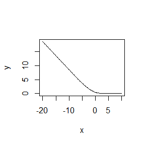

```r
set.seed(1)
N<-1e2;b1<-0;b2<-1;b3<--1
x1<-rpois(N,1);x2<-rexp(N,1);x3<-rbinom(N,1,0.5)#随机量
s<-function(x){
  p <- 1/(1+exp(-x)*exp(-b1*x1-b2*x2-b3*x3))
  return(-log(mean(p)))
}
x<-seq(-20,10,length=200);y<-numeric(200)
for (i in 1:200) {
  y[i]<-s(x[i])
}
plot(x,y,type="l")#由于s函数中x可以为数组，所以直接curve(s)会报错
```

### hw7_Exercises 9.4

Q: Implement a random walk Metropolis sampler for generating the standard Laplace distribution (see Exercise 3.2). For the increment, simulate from a normal distribution. Compare the chains generated when different variances are used for the proposal distribution. Also, compute the acceptance rates of each chain.

A:

目标分布$f(x)=\frac{e^{-|x|}}{2}$, 提议分布$g(x|y)=\frac{1}{\sqrt{2\pi }\sigma}e^{-\frac{|x-y|^2}{2\sigma^2}}.$

第t步的接受概率
$$\alpha=min \{
1,\frac{f(x')g(x^{(t-1)}|x')}{f( x^{(t-1)} )g(x'|x^{(t-1)})}
\}=min\{1,e^{|x|-|x'|}\}.$$

算法考虑了四种$\sigma$取值:0.05, 0.5, 2, 4. 链长均为5000, 初值为3.

四个链的生成如下:

```r
#生成这四个链
set.seed(111)
indept.Metropolis <- function(sigma_g, x0, N){#链生成
  #sigma_g为提议方差 x0为初始值 N链长
    x = numeric(N)
    x[1] = x0
    u = runif(N)
    k = 0
    for(i in 2:N){
      y = rnorm(1, x[i-1], sigma_g)#产生候选值
      porb = exp(abs(x[i-1])-abs(y))#计算接受概率
      if(u[i] <= porb)
        x[i] = y
      else{
        x[i] = x[i-1]
        k = k + 1
      }
    }
    return(list(x=x, k=k))
  }
chain_len = 5000
xt = numeric(chain_len)
sigma_g = c(0.05, 0.5, 2, 4)
x0 <- 3   # initial point
  indept1 <- indept.Metropolis(sigma_g[1], x0, chain_len)
  indept2 <- indept.Metropolis(sigma_g[2], x0, chain_len)
  indept3 <- indept.Metropolis(sigma_g[3], x0, chain_len)
  indept4 <- indept.Metropolis(sigma_g[4], x0, chain_len)
```

四个链的路径图如下:

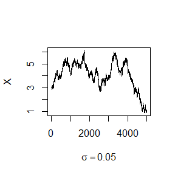

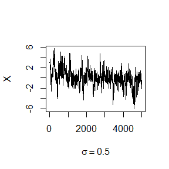

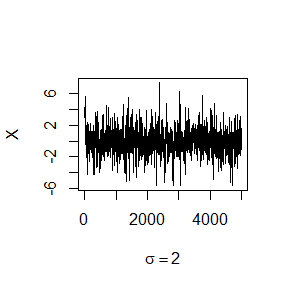

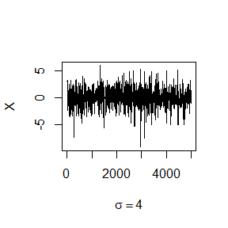

```r
  refline <- qcauchy(c(.025, .975))
  indept <- cbind(indept1$x, indept2$x, indept3$x, indept4$x)
  for (j in 1:4) {
      plot(indept[,j], type="l",
           xlab=bquote(sigma == .(round(sigma_g[j],3))),
           ylab="X", ylim=range(indept[,j]))
      abline(h=refline)
  }
```

可以看出后两个链收敛的比较好.

进一步画出四个链的QQ图：

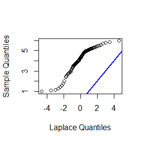

```r
a <- ppoints(100)
QR <- -log(1-2*abs(a-1/2))*sign(a-1/2)#quantiles of Laplace
Q1 <- quantile(indept1$x[300:5000], a)
Q2 <- quantile(indept2$x[300:5000], a)
Q3 <- quantile(indept3$x[300:5000], a)
Q4 <- quantile(indept4$x[300:5000], a)
qqplot(QR, Q1, main="",xlab="Laplace Quantiles", ylab="Sample Quantiles")
abline(0,1,col='blue',lwd=2)
```

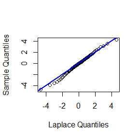

```r
qqplot(QR, Q2, main="",xlab="Laplace Quantiles", ylab="Sample Quantiles")
abline(0,1,col='blue',lwd=2)
```

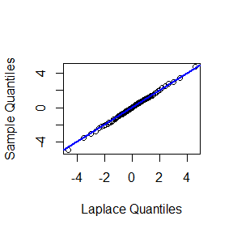

```r
qqplot(QR, Q3, main="",xlab="Laplace Quantiles", ylab="Sample Quantiles")
abline(0,1,col='blue',lwd=2)
```

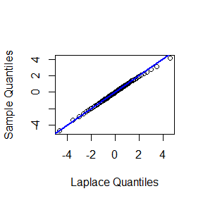

```r
qqplot(QR, Q4, main="",xlab="Laplace Quantiles", ylab="Sample Quantiles")
abline(0,1,col='blue',lwd=2)
```

四个链的直方图以及laplace分布密度函数曲线:

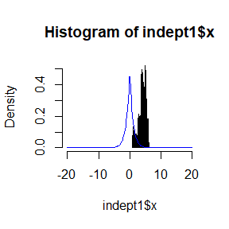

```r
x<-seq(-20,20,length=200)
y<-1/2*exp(-abs(x))
hist(indept1$x,xlim=c(-20,20),breaks = 100,col = "pink",freq=FALSE)
lines(x,y,col="blue")
```

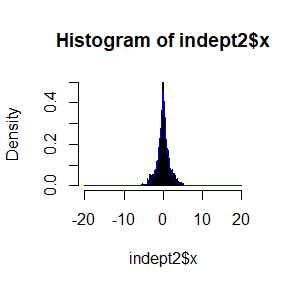

```r
hist(indept2$x,xlim=c(-20,20),breaks = 100,col = "pink",freq=FALSE)
lines(x,y,col="blue")
```

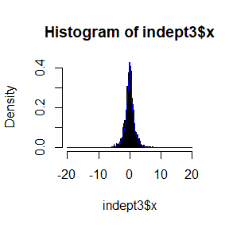

```r
hist(indept3$x,xlim=c(-20,20),breaks = 100,col = "pink",freq=FALSE)
lines(x,y,col="blue")
```

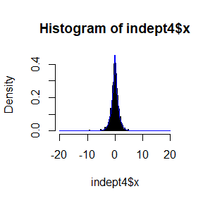

```r
hist(indept4$x,xlim=c(-20,20),breaks = 100,col = "pink",freq=FALSE)
lines(x,y,col="blue")
```

```r
print(c(indept1$k, indept2$k, indept3$k, indept4$k)/chain_len)#四个链的拒绝率
```

```
## [1] 0.0176 0.1760 0.4718 0.6586
```

提议分布方差$\sigma$取值:0.05, 0.5, 2, 4, 对应拒绝率: 0.0176 0.1760 0.4718 0.6586.

从四个链的QQ图和直方图来看,提议分布方差$\sigma$取值为0.05的时候链不收敛,数据分布和目标分布差异很大,提议分布方差$\sigma$取值为 0.5, 2, 4的时候链的QQ图和直方图表现差不多,但4最好.

### hw7_Exercises 9.7

Q: Implement a Gibbs sampler to generate a bivariate normal chain $(X_t, Y_t)$ with zero means, unit standard deviations, and correlation 0.9. Plot the generated sample after discarding a suitable burn-in sample. Fit a simple linear regression model $Y = \beta_0 + \beta_1X$ to the sample and check the residuals of the model for normality and constant variance.

A:

条件分布:
$$(X|Y)\sim
N(0.9Y,1-0.9^2),$$
$$(Y|X)\sim
N(0.9X,1-0.9^2).$$

```r
#initialize constants and parameters
N <- 5000 #length of chain
burn <- 1000 #burn-in length
X <- matrix(0, N, 2) #the chain, a bivariate sample
s1 <- sqrt(1-.9^2)
s2 <- sqrt(1-.9^2)
###### generate the chain #####
X[1, ] <- c(0, 0) #initialize
for (i in 2:N) {
x2 <- X[i-1, 2]
m1 <- .9 * x2
X[i, 1] <- rnorm(1, m1, s1)
x1 <- X[i, 1]
m2 <- .9* x1
X[i, 2] <- rnorm(1, m2, s2)
}
b <- burn + 1
x <- X[b:N, ]
x[1]
```

```
## [1] 0.1508055
```

抽样获得的样本图如下:

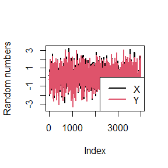

进行线性拟合结果如下:

```r
lm(x[,2] ~ x[,1])
```

```
##
## Call:
## lm(formula = x[, 2] ~ x[, 1])
##
## Coefficients:
## (Intercept)       x[, 1]
##   -0.005348     0.899347
```

```r
c(
cat('Means: ',round(colMeans(x),2)),
cat('\nStandard errors: ',round(apply(x,2,sd),2)),
cat('\nCorrelation coefficients: ', round(cor(x[,1],x[,2]),2)))
```

```
## Means:  -0.08 -0.07
## Standard errors:  0.99 0.99
## Correlation coefficients:  0.9
```

残差QQ图,直方图:

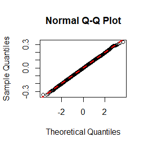

```r
er<-x[,1]-0.899347*x[,1]+0.005348
qqnorm(er)
qqline(er, col = "red", lwd = 2, lty = 2)
```

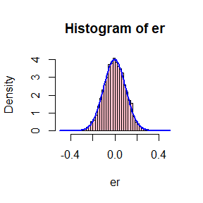

```r
hist(er,xlim=c(-.5,.5),breaks = 30,col = "pink",freq=FALSE)
xxx<-seq(-.5,.5,length=200);yyy<-dnorm(xxx,mean(er),sd(er))
lines(xxx,yyy,col="blue",lwd=2)
```

对残差分布与正态分布的QQ图以及对残差进行KS正态性检验：

```r
ks.test(scale(er),"pnorm")#scale(er)要先对数据进行标准化
```

```
##
##  Asymptotic one-sample Kolmogorov-Smirnov test
##
## data:  scale(er)
## D = 0.0083082, p-value = 0.9453
## alternative hypothesis: two-sided
```

p-value = 0.9453, 所以残差符合正态分布.

方差齐性检验: 下图是按照序列每100个残差对应的标准差散点图.

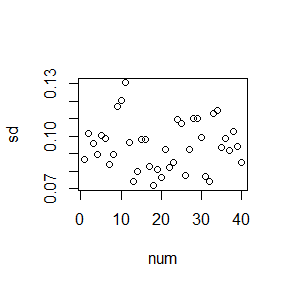

```r
wit<-100
num<-1:round(length(er)/wit)
sd<-numeric(length(num))
for (i in num) {
  sd[i]<-sd(er[(wit*(i-1)+1):(wit*i)])
}
plot(num,sd)
```

方差分布比较均匀.

### hw7_Exercises 9.10

Q: Refer to Example 9.1. Use the Gelman-Rubin method to monitor convergence of the chain, and run the chain until the chain has converged approximately to the target distribution according to $\hat{R < 1.2}$. (See Exercise 9.9.) Also use the coda package to check for convergence of the chain by the Gelman-Rubin method. Hints: See the help topics for the coda functions gelman.diag, gelman.plot, as.mcmc, and mcmc.list.

A:

```r
rm(list = ls())#删除当前工作环境中的所有对象。具体而言，这会删除所有已分配的变量、数据框、函数等，使得工作环境中不再包含这些对象

set.seed(123)
library("coda")
Gelman.Rubin <- function(psi) {#计算GR统计量
# psi[i,j] is the statistic psi(X[i,1:j])
# for chain in i-th row of X
  psi <- as.matrix(psi)#转为矩阵
  n <- ncol(psi)
  k <- nrow(psi)
  psi.means <- rowMeans(psi) #row means
  B <- n * var(psi.means) #between variance est.
  psi.w <- apply(psi, 1, "var") #within variances
  W <- mean(psi.w) #within est.
  v.hat <- W*(n-1)/n + (B/n) #upper variance est.
  r.hat <- v.hat / W #G-R statistic!!!!!!!!
  return(r.hat)
}
f <- function(x, sigma) {
  if (any(x < 0)) return (0)
  stopifnot(sigma > 0)
  return((x / sigma^2) * exp(-x^2 / (2*sigma^2)))
}
gen.chain<-function(sigma,N,x1){
  x<-numeric(N)
  x[1]<-x1
  u <- runif(N)
  for (i in 2:N) {
    xt <- x[i-1]
    y <- rchisq(1, df = xt)
    num <- f(y, sigma) * dchisq(xt, df = y)
    den <- f(xt, sigma) * dchisq(y, df = xt)
    if (u[i] <= num/den) x[i] <- y
    else x[i] <- xt
  }
  return(x)
}
n <- 10000
sigma <- 4
k<-3  #number of chains
b <- 1000 #burn-in length

#choose overdispersed initial values
x0 <- c(rchisq(1, df=1),rchisq(1, df=2),rchisq(1, df=3))
#generate the chains
X <- matrix(0, nrow=k, ncol=n)
for (i in 1:k)
  X[i, ] <- gen.chain(sigma, n, x0[i])

#compute diagnostic statistics
psi <- t(apply(X, 1, cumsum))
for (i in 1:nrow(psi))
  psi[i,] <- psi[i,] / (1:ncol(psi))
```

最后的GR统计量：

```r
print(Gelman.Rubin(psi))
```

```
## [1] 1.005155
```

画出3个链的psi

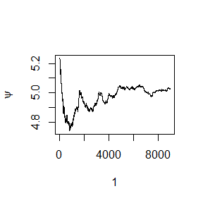

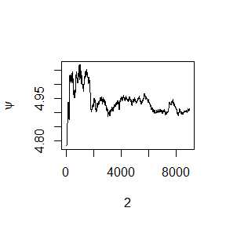

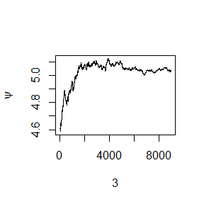

```r
for (i in 1:k)
  plot(psi[i, (b+1):n], type="l",xlab=i, ylab=bquote(psi))
```

在链中GR统计量的变化曲线：

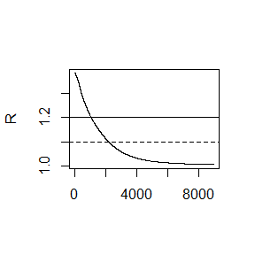

```r
#plot the sequence of R-hat statistics
rhat <- rep(0, n)
for (j in (b+1):n)
  rhat[j] <- Gelman.Rubin(psi[,1:j])
plot(rhat[(b+1):n], type="l", xlab="", ylab="R")
abline(h=1.1, lty=2)
abline(h=1.2,lty=1)
```

从图线中看，GR统计量符合$\hat{R}<1.2$的要求.

使用coda包检验：

```r
l1<-as.mcmc(X[1,])
l2<-as.mcmc(X[2,])
l3<-as.mcmc(X[3,])
l<-mcmc.list(l1,l2,l3)
gelman.diag(l)
```

```
## Potential scale reduction factors:
##
##      Point est. Upper C.I.
## [1,]          1          1
```

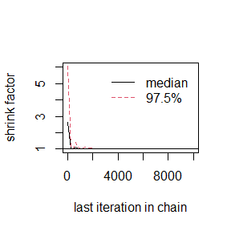

```r
gelman.plot(l)
```